# Projet statistique :

## Charger les données :

### Installer les packages nécessaires :

```r
#install.packages("xlsx")
```

### Charger les données :

```r
# xlsx files
library(xlsx)
my_data <- read.xlsx("dataset.xlsx",sheetIndex = 1,as.data.frame = T,encoding = 'UTF-8')
```

### nommer les colonnes :

```r
my_col_names=c('date','a_suivi','performer_travail_projet_1','motivation_certificat_1','trouver_emploi_1','mooc_inclu_etude_1','edt_chargee_1','plateformes_connues','aide_financiere_1','prix_1','outils_exercices_1','sciences_donnees_1','informatique_1','sciences_physiques_1','business_1','arts_1','langues_1','sciences_sociales_1','performer_travail_projet','motivation_certificat','trouver_emploi','nbr_certificat','satisfait_gestion_temps','objectifs_atteints','satisfaction','vacances_etude','temps_alloue_cours','mooc_inclu_etude','edt_chargee','plateformes_utilisees','videos_cours','transcription','diapositives_cours','forum_discussion','examens_exercices','accompagnement_pedagogique','aides_financiere','prix','outils_exercice','sciences_donnees','informatique','sciences_physiques','business','arts','langues','sciences_sociales','sexe','pays','age','est_etudiant','niveau_actuel','formation','background','mail','commentaire')
colnames(my_data)<-my_col_names
```

### Choisir lignes intérressants :

```r
## j'ai nettoyé les lignes à la main donc on prend tout les lignes
my_data2<-my_data[c(1:nrow(my_data)),]
```

### Eliminer les colonnes : mail, date

```r
my_data2$date<-NULL
my_data2$mail<-NULL
my_data2$commentaire<-NULL
```

### créer les dataframes nécessaires:

#### librairie pour filtrer les lignes :

```r
library("dplyr")
str(my_data2)
```

```
## 'data.frame':    134 obs. of  52 variables:
##  $ a_suivi                   : Factor w/ 3 levels "Jamais","Oui, je l'ai suivi et j'ai réussi",..: 2 2 3 2 2 2 3 2 2 2 ...
##  $ performer_travail_projet_1: Factor w/ 4 levels "D'accord","Désaccord",..: NA NA NA NA NA NA NA NA NA NA ...
##  $ motivation_certificat_1   : Factor w/ 4 levels "D'accord","Désaccord",..: NA NA NA NA NA NA NA NA NA NA ...
##  $ trouver_emploi_1          : Factor w/ 4 levels "D'accord","Désaccord",..: NA NA NA NA NA NA NA NA NA NA ...
##  $ mooc_inclu_etude_1        : Factor w/ 2 levels "Non","Oui": NA NA NA NA NA NA NA NA NA NA ...
##  $ edt_chargee_1             : Factor w/ 2 levels "Non","Oui": NA NA NA NA NA NA NA NA NA NA ...
##  $ plateformes_connues       : Factor w/ 9 levels "Coursera","Coursera, Edx",..: NA NA NA NA NA NA NA NA NA NA ...
##  $ aide_financiere_1         : Factor w/ 2 levels "Non","Oui": NA NA NA NA NA NA NA NA NA NA ...
##  $ prix_1                    : num  NA NA NA NA NA NA NA NA NA NA ...
##  $ outils_exercices_1        : Factor w/ 1 level "Oui": NA NA NA NA NA NA NA NA NA NA ...
##  $ sciences_donnees_1        : Factor w/ 3 levels "Inintéressant",..: NA NA NA NA NA NA NA NA NA NA ...
##  $ informatique_1            : Factor w/ 3 levels "Inintéressant",..: NA NA NA NA NA NA NA NA NA NA ...
##  $ sciences_physiques_1      : Factor w/ 3 levels "Inintéressant",..: NA NA NA NA NA NA NA NA NA NA ...
##  $ business_1                : Factor w/ 3 levels "Inintéressant",..: NA NA NA NA NA NA NA NA NA NA ...
```

[output cut: 38 more lines]

```r
#change from factor to numeric the feature : temps_alloue_cours
my_data2$temps_alloue_cours<-as.numeric(my_data2$temps_alloue_cours)
```

#### jamais suivi :

```r
data_jamais<-filter(my_data2,a_suivi=="Jamais")
# supprimer les colonnes avec que de Nans :
data_jamais<-data_jamais[ , ! apply( data_jamais , 2 , function(x) all(is.na(x)) ) ]
# Write CSV in R
write.csv(data_jamais, file = "data_jamais.csv")
```

```r
str(data_jamais)
```

```
## 'data.frame':    19 obs. of  24 variables:
##  $ a_suivi                   : Factor w/ 3 levels "Jamais","Oui, je l'ai suivi et j'ai réussi",..: 1 1 1 1 1 1 1 1 1 1 ...
##  $ performer_travail_projet_1: Factor w/ 4 levels "D'accord","Désaccord",..: 3 1 3 3 3 4 1 4 4 1 ...
##  $ motivation_certificat_1   : Factor w/ 4 levels "D'accord","Désaccord",..: 1 1 3 1 1 1 4 1 4 1 ...
##  $ trouver_emploi_1          : Factor w/ 4 levels "D'accord","Désaccord",..: 4 2 3 2 2 3 1 3 4 3 ...
##  $ mooc_inclu_etude_1        : Factor w/ 2 levels "Non","Oui": 2 2 2 2 2 2 1 2 2 1 ...
##  $ edt_chargee_1             : Factor w/ 2 levels "Non","Oui": 1 1 1 2 2 1 2 2 1 2 ...
##  $ plateformes_connues       : Factor w/ 9 levels "Coursera","Coursera, Edx",..: 8 8 1 4 7 5 3 6 8 2 ...
##  $ aide_financiere_1         : Factor w/ 2 levels "Non","Oui": 1 1 1 2 1 1 2 1 2 2 ...
##  $ prix_1                    : num  NA 40 NA 50 0 NA 20 20 5 5 ...
##  $ outils_exercices_1        : Factor w/ 1 level "Oui": 1 1 1 1 1 1 1 1 1 1 ...
##  $ sciences_donnees_1        : Factor w/ 3 levels "Inintéressant",..: 2 3 3 2 2 2 2 3 2 2 ...
##  $ informatique_1            : Factor w/ 3 levels "Inintéressant",..: 2 2 2 3 2 2 2 3 2 2 ...
##  $ sciences_physiques_1      : Factor w/ 3 levels "Inintéressant",..: 3 2 2 3 2 2 2 2 2 1 ...
##  $ business_1                : Factor w/ 3 levels "Inintéressant",..: 2 2 2 2 2 2 1 3 2 3 ...
##  $ arts_1                    : Factor w/ 3 levels "Inintéressant",..: 3 3 3 1 2 3 2 1 2 2 ...
##  $ langues_1                 : Factor w/ 2 levels "Interessant",..: 1 1 1 1 1 1 1 2 1 1 ...
##  $ sciences_sociales_1       : Factor w/ 3 levels "Inintéressant",..: 3 2 3 1 2 2 3 3 2 2 ...
##  $ sexe                      : Factor w/ 2 levels "Femme","Homme": 2 2 2 2 1 2 2 2 2 2 ...
##  $ pays                      : Factor w/ 13 levels "Autre","Burkinafasso",..: 4 5 11 1 5 5 5 5 4 8 ...
##  $ age                       : num  20 23 32 28 21 20 22 20 35 21 ...
##  $ est_etudiant              : Factor w/ 2 levels "Non","Oui": 2 2 2 2 2 2 2 2 2 2 ...
##  $ niveau_actuel             : Factor w/ 5 levels "BAC +2","BAC +3",..: 4 4 5 4 2 1 3 2 4 3 ...
##  $ formation                 : Factor w/ 6 levels "FIG","FIL","FIP",..: 1 1 6 5 1 3 1 3 6 1 ...
##  $ background                : Factor w/ 4 levels "Autre école",..: 3 3 4 4 4 2 4 2 4 3 ...
```

#### suivi terminé et non terminé :

```r
data_suivi<-filter(my_data2,a_suivi  %in% c("Oui, je l'ai suivi mais je ne l'ai pas terminé", "Oui, je l'ai suivi et j'ai réussi" ))
data_suivi<-data_suivi[ , ! apply( data_suivi , 2 , function(x) all(is.na(x)) ) ]
write.csv(data_suivi, file = "data_suivi.csv")
```

#### suivi mais pas terminé :

```r
data_non_termine<-filter(my_data2,a_suivi  %in% c("Oui, je l'ai suivi mais je ne l'ai pas terminé"))
data_non_termine<-data_non_termine[ , ! apply( data_non_termine , 2 , function(x) all(is.na(x)) ) ]
write.csv(data_non_termine, file = "data_non_termine.csv")
```

#### suivi et terminé :

```r
data_termine<-filter(my_data2,a_suivi  %in% c( "Oui, je l'ai suivi et j'ai réussi" ))
data_termine<-data_termine[ , ! apply( data_termine , 2 , function(x) all(is.na(x)) ) ]
write.csv(data_termine, file = "data_termine.csv")
```

## Exploration des données : suivi terminé/non terminé

#### Summary about all features :

```r
summary(data_suivi)
```

```
##                                            a_suivi
##  Jamais                                        : 0
##  Oui, je l'ai suivi et j'ai réussi             :73
##  Oui, je l'ai suivi mais je ne l'ai pas terminé:42
##
##
##
##
##              performer_travail_projet              motivation_certificat
##  D'accord                :51          D'accord                :27
##  Désaccord               : 4          Désaccord               :25
##  Neutre                  :22          Neutre                  :17
##  Tout à fait d'acord     :37          Tout à fait d'acord     :30
##  Tout à fait en désaccord: 1          Tout à fait en désaccord:16
##
##
##                   trouver_emploi nbr_certificat
##  D'accord                :23     Min.   :  0.000
##  Désaccord               :30     1st Qu.:  0.000
##  Neutre                  :32     Median :  1.000
##  Tout à fait d'acord     : 6     Mean   :  2.157
##  Tout à fait en désaccord:24     3rd Qu.:  1.000
##                                  Max.   :100.000
##
##              satisfait_gestion_temps                objectifs_atteints
##  D'accord                :33         D'accord                :44
##  Désaccord               :27         Désaccord               :19
##  Neutre                  :28         Neutre                  :33
##  Tout à fait d'accord    :22         Tout à fait d'accord    :17
##  Tout à fait en désaccord: 5         Tout à fait en désaccord: 2
##
##
##   satisfaction       vacances_etude temps_alloue_cours mooc_inclu_etude
##  Min.   : 1.0   Les deux    :58     Min.   : 1.00      Non:25
##  1st Qu.: 5.5   Les vacances: 9     1st Qu.: 8.00      Oui:90
##  Median : 7.0   Vos études  :48     Median : 9.00
##  Mean   : 6.6                       Mean   : 9.61
##  3rd Qu.: 8.0                       3rd Qu.:12.00
##  Max.   :10.0                       Max.   :18.00
##                                     NA's   :10
```

[output cut: 57 more lines]

```
##  France       :69   Min.   :18.0   Non:  2      BAC +2        : 7
##  Maroc        :23   1st Qu.:21.0   Oui:113      BAC +3        :20
##  Tunisie      : 9   Median :22.0                BAC +4        :36
##  Autre        : 6   Mean   :22.1                BAC +5        :45
##  Côte d'ivoire: 2   3rd Qu.:23.0                BAC +6 ou plus: 4
##  Burkinafasso : 1   Max.   :50.0                NA's          : 3
##  (Other)      : 5
##                formation        background
##  FIG                :97   Autre école: 4
##  FIL                : 4   DUT        : 4
##  FIP                : 3   Prépa      :95
##  Master de recherche: 1   Université :12
##  Master of science  : 7
##  Master spécialisé  : 3
##
```

### Boxplot pour les variables numériques:

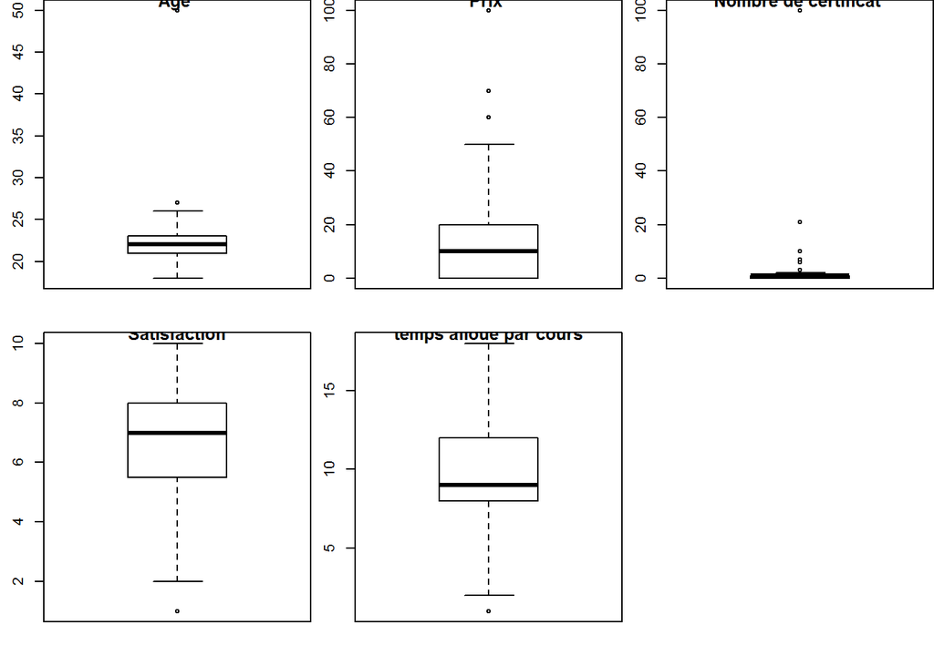

```r
par(mfrow=c(2,3),mar=c(2.5,2.5,0,0))
boxplot(data_suivi$age,main="Age ")
boxplot(data_suivi$prix,main="Prix ")
boxplot(data_suivi$nbr_certificat,main="Nombre de certificat ")
boxplot(data_suivi$satisfaction,main="Satisfaction")
boxplot(data_suivi$temps_alloue_cours,main="temps alloué par cours")
```

Commentaire : Toutes les variables présentent des outliers surtout prix et nombre de certificat.

### exploration des variables qualitatives :

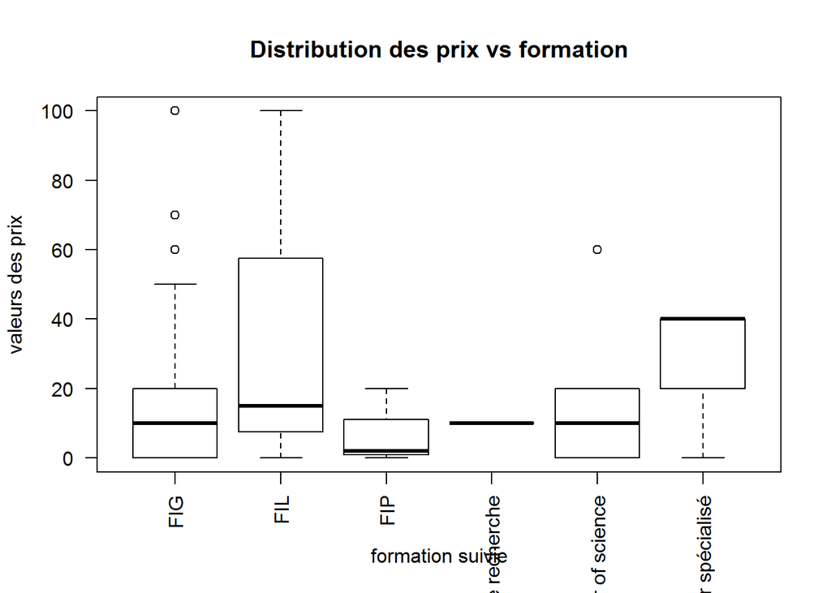

```r
boxplot(data_suivi$prix~data_suivi$formation,data=data_suivi, main="Distribution des prix vs formation",ylab="valeurs des prix", xlab="formation suivie",las=2)
```

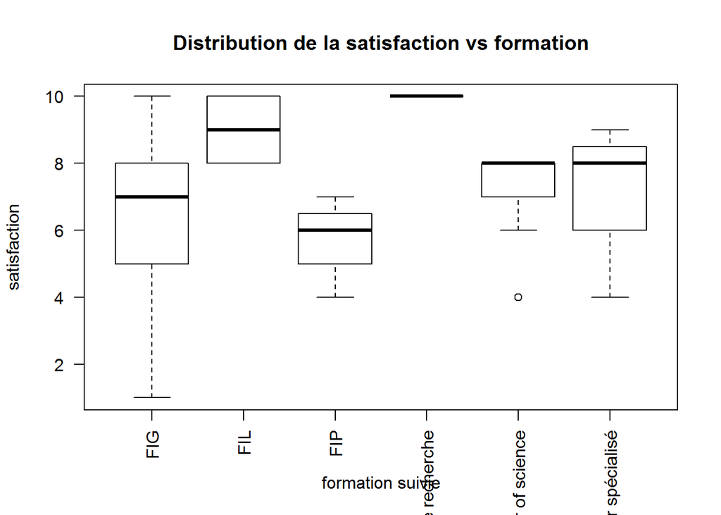

```r
boxplot(data_suivi$satisfaction~data_suivi$formation,data=data_suivi, main="Distribution de la satisfaction vs formation",ylab="satisfaction", xlab="formation suivie",las=2)
```

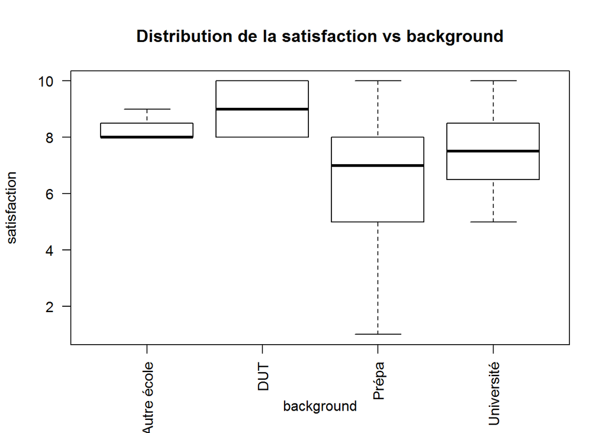

```r
boxplot(data_suivi$satisfaction~data_suivi$background,data=data_suivi, main="Distribution de la satisfaction vs background",ylab="satisfaction", xlab="background",las=2)
```

[figure not shown]

```r
boxplot(data_suivi$satisfaction~data_suivi$sexe,data=data_suivi, main="Distribution de la satisfaction vs background",ylab="satisfaction", xlab="sexe",las=2)
```

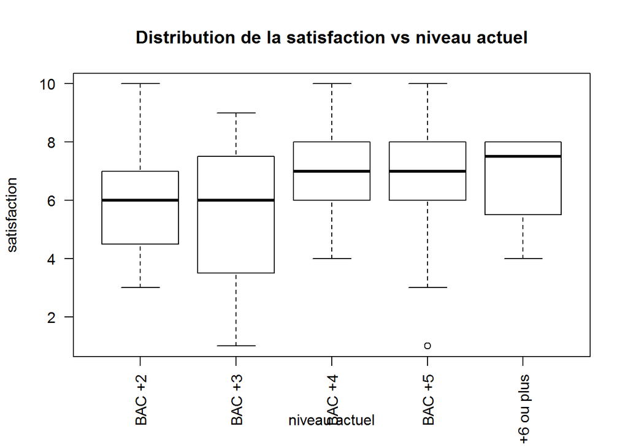

```r
boxplot(data_suivi$satisfaction~data_suivi$niveau_actuel,data=data_suivi, main="Distribution de la satisfaction vs niveau actuel",ylab="satisfaction", xlab="niveau actuel",las=2)
```

[figure not shown]

```r
boxplot(data_suivi$satisfaction~data_suivi$vacances_etude,data=data_suivi, main="Distribution du temps alloué par cours vs vacances_etudes",ylab="satisfaction", xlab="vacances_etudes",las=2)
```

[figure not shown]

```r
boxplot(data_suivi$satisfaction~data_suivi$motivation_certificat,data=data_suivi, main="Distribution du temps alloué par cours vs motivation certificat",ylab="satisfaction", xlab="motivation certificat",las=2)
```

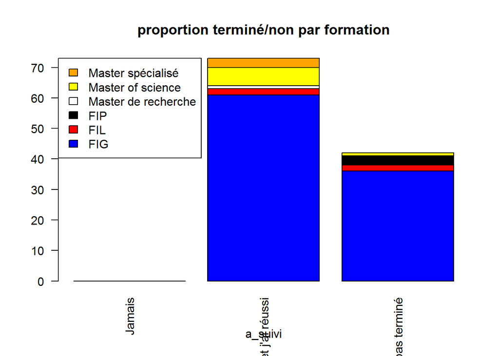

```r
count1 <- table(data_suivi$formation, data_suivi$a_suivi)
barplot(count1, main="proportion terminé/non par formation", xlab="a_suivi", col=c("blue","red","black","white","yellow","orange"),las=2,legend.text = T,args.legend=list(x = "topleft"))
```

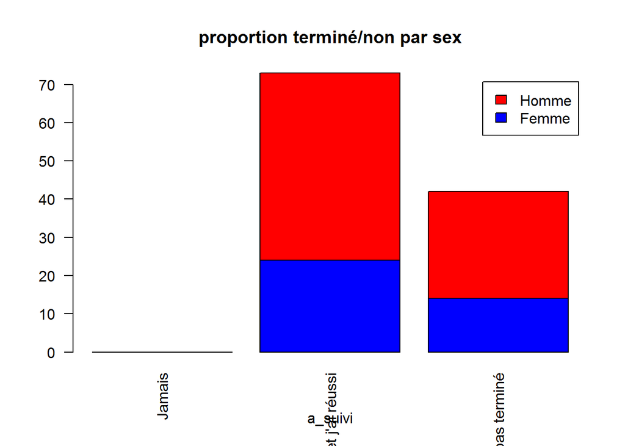

```r
count2 <- table(data_suivi$sexe, data_suivi$a_suivi)
barplot(count2, main="proportion terminé/non par sex", xlab="a_suivi", col=c("blue","red"),legend = rownames(count2),las=2)
```

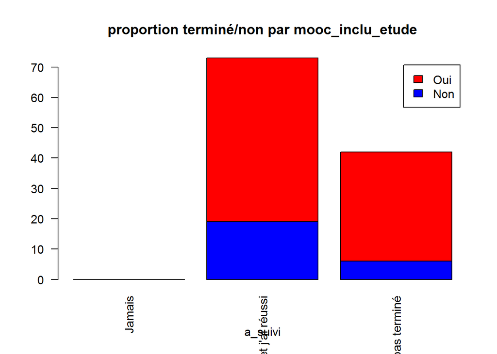

```r
count3 <- table(data_suivi$mooc_inclu_etude, data_suivi$a_suivi)
barplot(count3, main="proportion terminé/non par mooc_inclu_etude", xlab="a_suivi", col=c("blue","red"),legend = rownames(count3),las=2)
```

la majoroté des personnes qui n’ont pas terminé ses moocs ils ont fait ses mooc pendant leur etude=> ce qui peût être naturelle car il y une charge de travail pendant les études.

### Test statistiques :

#### Hypthèse 1 : la terminaison des mooc ne depend pas du genre :

Chi-square test basics :

Chi-square test examines whether rows and columns of a contingency table are statistically significantly associated.

Null hypothesis (H0): the row and the column variables of the contingency table are independent. Alternative hypothesis (H1): row and column variables are dependent

```r
# contingency table
table(data_suivi$a_suivi,data_suivi$sexe)
```

```
##
##                                                  Femme Homme
##   Jamais                                             0     0
##   Oui, je l'ai suivi et j'ai réussi                 24    49
##   Oui, je l'ai suivi mais je ne l'ai pas terminé    14    28
```

```r
chisq_sexe <- chisq.test(data_suivi$a_suivi,data_suivi$sexe)
chisq_sexe
```

```
##
##  Pearson's Chi-squared test with Yates' continuity correction
##
## data:  data_suivi$a_suivi and data_suivi$sexe
## X-squared = 0, df = 1, p-value = 1
```

le test donne une p-value de 1 ce qui permet avec un rique de 5% de garder l’hypthèse nulle et donc conclure que les deux variables catégorielles sont indépendentes.

#### Hypthèse 2 : la terminaison des mooc ne depend pas de la formation suivie :

```r
# contingency table
table(data_suivi$a_suivi,data_suivi$formation)
```

```
##
##                                                  FIG FIL FIP
##   Jamais                                           0   0   0
##   Oui, je l'ai suivi et j'ai réussi               61   2   0
##   Oui, je l'ai suivi mais je ne l'ai pas terminé  36   2   3
##
##                                                  Master de recherche
##   Jamais                                                           0
##   Oui, je l'ai suivi et j'ai réussi                                1
##   Oui, je l'ai suivi mais je ne l'ai pas terminé                   0
##
##                                                  Master of science
##   Jamais                                                         0
##   Oui, je l'ai suivi et j'ai réussi                              6
##   Oui, je l'ai suivi mais je ne l'ai pas terminé                 1
##
##                                                  Master spécialisé
##   Jamais                                                         0
##   Oui, je l'ai suivi et j'ai réussi                              3
##   Oui, je l'ai suivi mais je ne l'ai pas terminé                 0
```

```r
chisq_formation <- chisq.test(data_suivi$a_suivi,data_suivi$formation)
chisq_formation
```

```
##
##  Pearson's Chi-squared test
##
## data:  data_suivi$a_suivi and data_suivi$formation
## X-squared = 9.3367, df = 5, p-value = 0.09637
```

Avec un risque de 5% on garde H0, donc les les deux variables sont indépendentes.

Il y a une forte association positive entre la colonne FIP et la rangée “Oui, je l’ai suivi..pas terminé”

#### Hypthèse 3 : la terminaison des mooc ne depend pas du background du répondant :

```r
table(data_suivi$a_suivi,data_suivi$background)
```

```
##
##                                                  Autre école DUT Prépa
##   Jamais                                                   0   0     0
##   Oui, je l'ai suivi et j'ai réussi                        4   2    59
##   Oui, je l'ai suivi mais je ne l'ai pas terminé           0   2    36
##
##                                                  Université
##   Jamais                                                  0
##   Oui, je l'ai suivi et j'ai réussi                       8
##   Oui, je l'ai suivi mais je ne l'ai pas terminé          4
```

```r
chisq_backround <- chisq.test(data_suivi$a_suivi,data_suivi$background)
chisq_backround
```

```
##
##  Pearson's Chi-squared test
##
## data:  data_suivi$a_suivi and data_suivi$background
## X-squared = 2.7447, df = 3, p-value = 0.4327
```

Toujours avec un risque de 5% on accepte H0==> les colonnes et les lignes sont indépendents. ####Hypthèse 4: la terminaison des mooc ne depend pas de la plateforme utilisée :

```r
#table(data_suivi$a_suivi,data_suivi$plateformes_utilisees)
```

```r
chisq_plateforme <- chisq.test(data_suivi$a_suivi,data_suivi$plateformes_utilisees)
chisq_plateforme
```

```
##
##  Pearson's Chi-squared test
##
## data:  data_suivi$a_suivi and data_suivi$plateformes_utilisees
## X-squared = 28.772, df = 29, p-value = 0.477
```

même conclusion

#### Hypthèse 4: la terminaison des mooc ne depend pas de périodes de suivi des mooc :

```r
table(data_suivi$a_suivi,data_suivi$vacances_etude)
```

```
##
##                                                  Les deux Les vacances
##   Jamais                                                0            0
##   Oui, je l'ai suivi et j'ai réussi                    34            6
##   Oui, je l'ai suivi mais je ne l'ai pas terminé       24            3
##
##                                                  Vos études
##   Jamais                                                  0
##   Oui, je l'ai suivi et j'ai réussi                      33
##   Oui, je l'ai suivi mais je ne l'ai pas terminé         15
```

```r
chisq_periode <- chisq.test(data_suivi$a_suivi,data_suivi$vacances_etude)
chisq_periode
```

```
##
##  Pearson's Chi-squared test
##
## data:  data_suivi$a_suivi and data_suivi$vacances_etude
## X-squared = 1.2052, df = 2, p-value = 0.5474
```

=====================================================================================

On veut comparer le degré de satisfaction envers les moocs en fonction de la catégorie du répondeur à notre sondage : le sexe a-t-il une influence sur la satisfaction? Et qu’en est-t-il du niveau actuel du répondeur? De sa formation à l’école? Du son background?

#### Hypothèses 5 : Le degrée de satisfaction des femmes et des hommes est le même :

```r
satisf_homme_femme<-data_suivi[,c("satisfaction","sexe")]
str(satisf_homme_femme)
```

```
## 'data.frame':    115 obs. of  2 variables:
##  $ satisfaction: num  7 10 9 6 1 7 3 6 7 6 ...
##  $ sexe        : Factor w/ 2 levels "Femme","Homme": 2 2 2 2 2 1 2 2 2 2 ...
```

```r
library(plyr); library(dplyr)
res<-ddply(satisf_homme_femme,~sexe,summarise,mean=mean(satisfaction),sd=sd(satisfaction))
```

le resultat est le suivant :

| sexe | mean | sd |
| --- | --- | --- |
| Femme | 6.578947 | 1.926088 |
| Homme | 6.610390 | 1.987830 |

```r
homme_series<-filter(satisf_homme_femme,sexe=="Homme")
shapiro.test(homme_series$satisfaction)
```

```
##
##  Shapiro-Wilk normality test
##
## data:  homme_series$satisfaction
## W = 0.93798, p-value = 0.0009714
```

La distribution de la satisfcation des hommes n’est pas normale. On procéde de même pour les femmes :

```r
femme_series<-filter(satisf_homme_femme,sexe=="Femme")
shapiro.test(femme_series$satisfaction)
```

```
##
##  Shapiro-Wilk normality test
##
## data:  femme_series$satisfaction
## W = 0.92978, p-value = 0.01974
```

Même conclustion qu’avant. Donc on doit utiliser un test de Wilcoxon qui est non paramétriques:

```r
wilcox.test(femme_series$satisfaction,homme_series$satisfaction)
```

```
##
##  Wilcoxon rank sum test with continuity correction
##
## data:  femme_series$satisfaction and homme_series$satisfaction
## W = 1449.5, p-value = 0.9374
## alternative hypothesis: true location shift is not equal to 0
```

Avec un risque de 5%, on accepte H0 et donc il n’y a pas de différence de satisfaction entre les hommes et les femmes.

#### Hypothèses 6: Le degrée de satisfaction est le même pour tout les niveaux d’études :

```r
satisf_niveau<-data_suivi[,c("satisfaction","niveau_actuel")]
str(satisf_niveau)
```

```
## 'data.frame':    115 obs. of  2 variables:
##  $ satisfaction : num  7 10 9 6 1 7 3 6 7 6 ...
##  $ niveau_actuel: Factor w/ 5 levels "BAC +2","BAC +3",..: 4 4 2 4 2 3 4 4 3 4 ...
```

```r
res2<-ddply(satisf_niveau,~niveau_actuel,summarise,mean=mean(satisfaction),sd=sd(satisfaction))
```

```r
bac2<-filter(satisf_niveau,niveau_actuel=="BAC +2")
shapiro.test(bac2$satisfaction)
```

```
##
##  Shapiro-Wilk normality test
##
## data:  bac2$satisfaction
## W = 0.96061, p-value = 0.8239
```

===> avec un risque de 5% la distribution est normale pour BAC +2

```r
bac3<-filter(satisf_niveau,niveau_actuel=="BAC +3")
shapiro.test(bac3$satisfaction)
```

```
##
##  Shapiro-Wilk normality test
##
## data:  bac3$satisfaction
## W = 0.93991, p-value = 0.2389
```

==> avec un risque de 5% Distribution est normale pour BAC+3

```r
bac4<-filter(satisf_niveau,niveau_actuel=="BAC +4")
shapiro.test(bac4$satisfaction)
```

```
##
##  Shapiro-Wilk normality test
##
## data:  bac4$satisfaction
## W = 0.93636, p-value = 0.03917
```

==> avec un risque de 5% la distribution n’est pas normale pour BAC+4

```r
bac5<-filter(satisf_niveau,niveau_actuel=="BAC +5")
shapiro.test(bac5$satisfaction)
```

```
##
##  Shapiro-Wilk normality test
##
## data:  bac5$satisfaction
## W = 0.94592, p-value = 0.03567
```

==> avec un risque de 5% non normale pour BAC+5

```r
bac6<-filter(satisf_niveau,niveau_actuel=="BAC +6 ou plus")
shapiro.test(bac6$satisfaction)
```

```
##
##  Shapiro-Wilk normality test
##
## data:  bac6$satisfaction
## W = 0.79065, p-value = 0.08649
```

==> avec un risque de 5% ,normale pour BAC+6 Donc on va utiliser le test de wilcoxon : ####BAC+2 VS BAC+3 :

```r
wilcox.test(bac2$satisfaction,bac3$satisfaction)
```

```
##
##  Wilcoxon rank sum test with continuity correction
##
## data:  bac2$satisfaction and bac3$satisfaction
## W = 76, p-value = 0.7589
## alternative hypothesis: true location shift is not equal to 0
```

avec un risque de 5%, on accepte H0==> les deux niveau ont le même degré de satisfaction. ####BAC+3 VS BAC+4 :

```r
wilcox.test(bac3$satisfaction,bac4$satisfaction)
```

```
##
##  Wilcoxon rank sum test with continuity correction
##
## data:  bac3$satisfaction and bac4$satisfaction
## W = 222, p-value = 0.01681
## alternative hypothesis: true location shift is not equal to 0
```

Avec un risque de 5%, on rejete h0===> les deux niveau n’ont pas le même degré de satisfaction. Pour savoir qui est le plus satisfait, on fait le test suivant :

```r
wilcox.test(bac3$satisfaction,bac4$satisfaction,alternative = "greater")
```

```
##
##  Wilcoxon rank sum test with continuity correction
##
## data:  bac3$satisfaction and bac4$satisfaction
## W = 222, p-value = 0.992
## alternative hypothesis: true location shift is greater than 0
```

Avec un risque de 5%, on affirme que le degré de satisfaction des BAC+4 est plus grand à celui des BAC+3. ####BAC+4 VS BAC+5 :

```r
wilcox.test(bac4$satisfaction,bac5$satisfaction)
```

```
##
##  Wilcoxon rank sum test with continuity correction
##
## data:  bac4$satisfaction and bac5$satisfaction
## W = 848.5, p-value = 0.7129
## alternative hypothesis: true location shift is not equal to 0
```

avec un risque de 5%, on affirme que les deux niveau ont le même degré de satisfaction.

#### BAC+5 vS BAC+6 ou plus :

```r
wilcox.test(bac5$satisfaction,bac6$satisfaction)
```

```
##
##  Wilcoxon rank sum test with continuity correction
##
## data:  bac5$satisfaction and bac6$satisfaction
## W = 88, p-value = 0.9555
## alternative hypothesis: true location shift is not equal to 0
```

avec un risque de 5%, on affirme que les deux niveau ont le même degré de satisfaction.

### ACF:en cours …